STA504 HOMEWORK1

Jessica Choe(Jaeseong Choe)

```r
#0.preparing for analysis and Exploring the data

library(tidyverse)
math <- read_csv("C:/Users/user/Desktop/2020spring/504 data visualization/hw/hw1/student-mat.csv")
is.data.frame(math)
```

```
## [1] TRUE
```

```r
ls(math)
```

```
##  [1] "absences"   "activities" "address"    "age"        "Dalc"
##  [6] "failures"   "famrel"     "famsize"    "famsup"     "Fedu"
## [11] "Fjob"       "freetime"   "G1"         "G2"         "G3"
## [16] "goout"      "guardian"   "health"     "higher"     "internet"
## [21] "Medu"       "Mjob"       "nursery"    "paid"       "Pstatus"
## [26] "reason"     "romantic"   "school"     "schoolsup"  "sex"
## [31] "studytime"  "traveltime" "Walc"
```

```r
head(math)
```

```
## # A tibble: 6 x 33
##   school sex     age address famsize Pstatus  Medu  Fedu Mjob  Fjob  reason
##   <chr>  <chr> <dbl> <chr>   <chr>   <chr>   <dbl> <dbl> <chr> <chr> <chr>
## 1 GP     F        18 U       GT3     A           4     4 at_h~ teac~ course
## 2 GP     F        17 U       GT3     T           1     1 at_h~ other course
## 3 GP     F        15 U       LE3     T           1     1 at_h~ other other
## 4 GP     F        15 U       GT3     T           4     2 heal~ serv~ home
## 5 GP     F        16 U       GT3     T           3     3 other other home
## 6 GP     M        16 U       LE3     T           4     3 serv~ other reput~
## # ... with 22 more variables: guardian <chr>, traveltime <dbl>,
## #   studytime <dbl>, failures <dbl>, schoolsup <chr>, famsup <chr>,
## #   paid <chr>, activities <chr>, nursery <chr>, higher <chr>,
## #   internet <chr>, romantic <chr>, famrel <dbl>, freetime <dbl>,
## #   goout <dbl>, Dalc <dbl>, Walc <dbl>, health <dbl>, absences <dbl>,
## #   G1 <dbl>, G2 <dbl>, G3 <dbl>
```

```r
#1.code:
math$school_labeled <- factor(math$school,
                    labels=c("Gabriel Pereira",
                             "Mousinho da Silveira"))
data.frame(table(math$school_labeled)) # One way to view the table- in a matrix format.
```

```
##                   Var1 Freq
## 1      Gabriel Pereira  349
## 2 Mousinho da Silveira   46
```

#1.answer: Gabriel Pereira(GP):349, Mousinho da Silveira(MS):46

```r
#2.code:
#(1)step1: calculate the count
reputation_count <- math %>% group_by(reason)%>%
                    summarise(total = n())
reputation_count
```

```
## # A tibble: 4 x 2
##   reason     total
##   <chr>      <int>
## 1 course       145
## 2 home         109
## 3 other         36
## 4 reputation   105
```

```r
#(2)step2: calcute the percent for reputation.
reputation_percent <- reputation_count%>% mutate(percent = total / sum(total))
reputation_percent
```

```
## # A tibble: 4 x 3
##   reason     total percent
##   <chr>      <int>   <dbl>
## 1 course       145  0.367
## 2 home         109  0.276
## 3 other         36  0.0911
## 4 reputation   105  0.266
```

#2.answer: 26.58%(=0.26) of students chose their school based on reputation.

```r
#3.code
math$sex_labeled <- factor(math$sex,
                    labels=c("Female","Male"))
Grade1_over10 <- math %>% dplyr::filter(G1>10)

F_Grade1_over10 <- Grade1_over10 %>%
                  group_by(sex_labeled) %>%
                  summarise(total = n()) %>%
                  mutate(percent = total / sum(total))
F_Grade1_over10
```

```
## # A tibble: 2 x 3
##   sex_labeled total percent
##   <fct>       <int>   <dbl>
## 1 Female         97   0.480
## 2 Male          105   0.520
```

#3.answer:The percent of female among students whose first period grade is greater than 10 is 48.0198%

```r
#4. code:
#(1)change the class(type) from numeric to factor
math$studyT_labeled <- factor(math$studytime,
                    labels=c("Less than2", "2 to 5hrs",
                             "5 to 10hrs","More than10"))
#(2)set order for the categorical variables.
math$studyT_labeled <- ordered(math$studyT_labeled,
                    labels=c("Less than2", "2 to 5hrs",
                             "5 to 10hrs","More than10"))
head(math$studyT_labeled)
```

```
## [1] 2 to 5hrs  2 to 5hrs  2 to 5hrs  5 to 10hrs 2 to 5hrs  2 to 5hrs
## Levels: Less than2 < 2 to 5hrs < 5 to 10hrs < More than10
```

```r
#(3) filter by studytime(=5 to 10 hours) and activities(=yes).
activityY_Study5to10 <-math%>%
          dplyr::filter(studyT_labeled=="5 to 10hrs" &
          activities=="yes")
#(4) summarize with mean and standard deviation for the 2nd grade
summary_2ndG <- activityY_Study5to10  %>%
              summarize(mean(G2),sd(G2))
summary_2ndG
```

```
## # A tibble: 1 x 2
##   `mean(G2)` `sd(G2)`
##        <dbl>    <dbl>
## 1       11.2     3.58
```

#4. answer:mean(Second grade):11.25 sd(Second grade):3.58

```r
#5. code:
#(1) create new traveltime variable(=travelT_labeled) to change its type and labels.
#(study time is already labeled in problem 4)
class(math$traveltime)
```

```
## [1] "numeric"
```

```r
math$travelT_labeled <- factor(math$traveltime,
                    labels=c("<15min","15 to 30m",
                    "30m to 1 hr",">1hr"))

math$travelT_labeled <- ordered(math$travelT_labeled,
                       labels=c("<15min","15 to 30m","30m to 1 hr",">1hr"))
class(math$travelT_labeled)
```

```
## [1] "ordered" "factor"
```

```r
head(math$travelT_labeled)
```

```
## [1] 15 to 30m <15min    <15min    <15min    <15min    <15min
## Levels: <15min < 15 to 30m < 30m to 1 hr < >1hr
```

```r
#the type of traveltime_labeled is factor (ordered)

#(2)find the highest average final grade:
#1.group the data by traveltime and study time.
#2.find mean for each group.
#3.sort it from highest final grade(=G3)
table(math$travelT_labeled,math$studyT_labeled)
```

```
##
##               Less than2 2 to 5hrs 5 to 10hrs More than10
##   <15min              60       133         47          17
##   15 to 30m           31        51         16           9
##   30m to 1 hr         11        11          1           0
##   >1hr                 3         3          1           1
```

```r
math2 <- math %>% group_by(travelT_labeled, studyT_labeled)
summary_desc <- math2 %>%
          summarise(mean.final=mean(G3),n=n())%>%
           arrange(desc(mean.final))
summary_desc
```

```
## # A tibble: 15 x 4
## # Groups:   travelT_labeled [4]
##    travelT_labeled studyT_labeled mean.final     n
##    <ord>           <ord>               <dbl> <int>
##  1 >1hr            More than10         13        1
##  2 30m to 1 hr     5 to 10hrs          12        1
##  3 <15min          More than10         11.7     17
##  4 15 to 30m       5 to 10hrs          11.5     16
##  5 <15min          5 to 10hrs          11.4     47
##  6 <15min          Less than2          10.9     60
##  7 <15min          2 to 5hrs           10.4    133
##  8 >1hr            Less than2          10.3      3
##  9 15 to 30m       More than10         10.2      9
## 10 30m to 1 hr     2 to 5hrs           10.2     11
## 11 >1hr            5 to 10hrs          10        1
## 12 15 to 30m       2 to 5hrs            9.82    51
## 13 15 to 30m       Less than2           9.13    31
## 14 30m to 1 hr     Less than2           8.09    11
## 15 >1hr            2 to 5hrs            5.33     3
```

#5. answer: study time more than 10 hours (4) and travel time more than 1 hour(4) has the highest average of final period grade of 13.

However, n=1(only 1 observation) in this case so we cannot say it is the best combination for the best grade as the observation is too small as only 1 person.

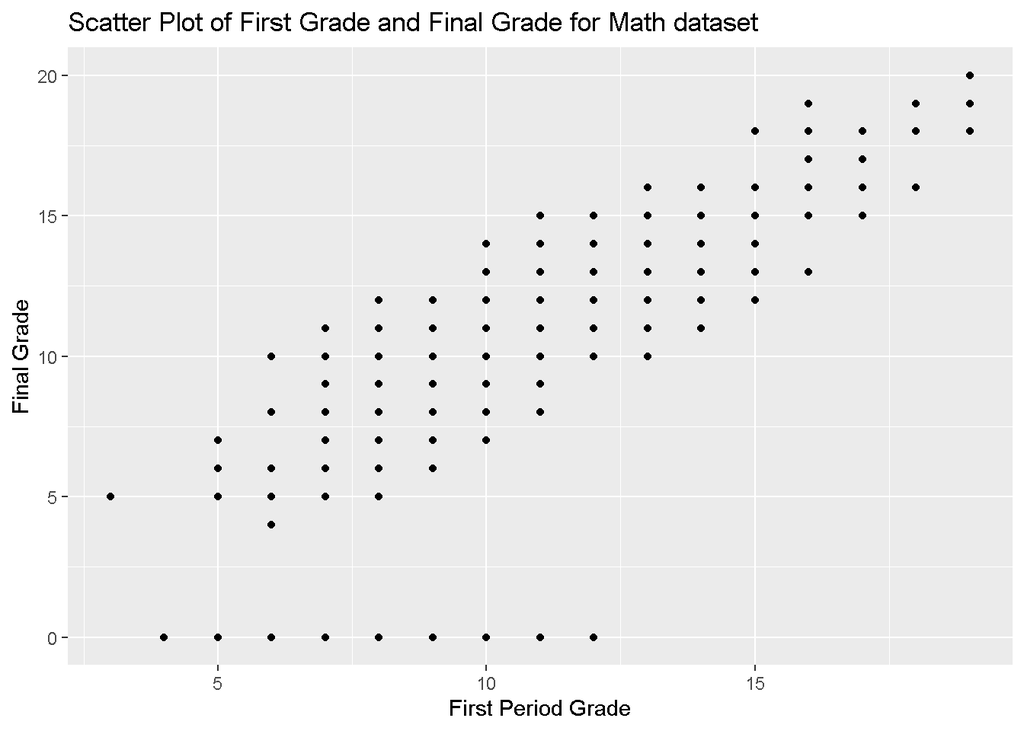

```r
#6. code:
ggplot()+
  geom_point(aes(x=G1, y=G3),data=math)+
  labs(x="First Period Grade",y="Final Grade",
       title="Scatter Plot of First Grade and Final Grade for Math dataset")
```

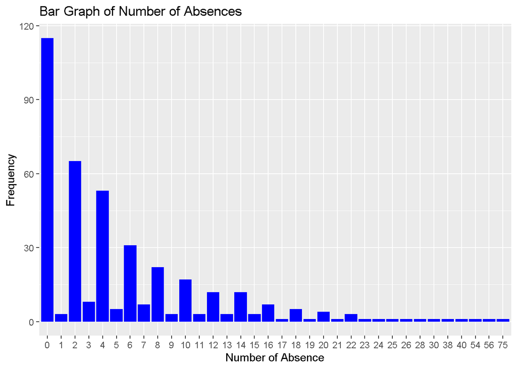

```r
#7. code:
#5 ways to create a plot to show the distribution of school absences.
#Except for (5)geom_density showing distribution in y-axis, all the rest show the frequencies.
#(1)using geom_col
absences <- data.frame(table(math$absences))

ggplot() +
  geom_col(aes(x=Var1,y=Freq),fill="blue",data=absences)+
  labs(x="Number of Absence",y="Frequency",
       title="Bar Graph of Number of Absences")
```

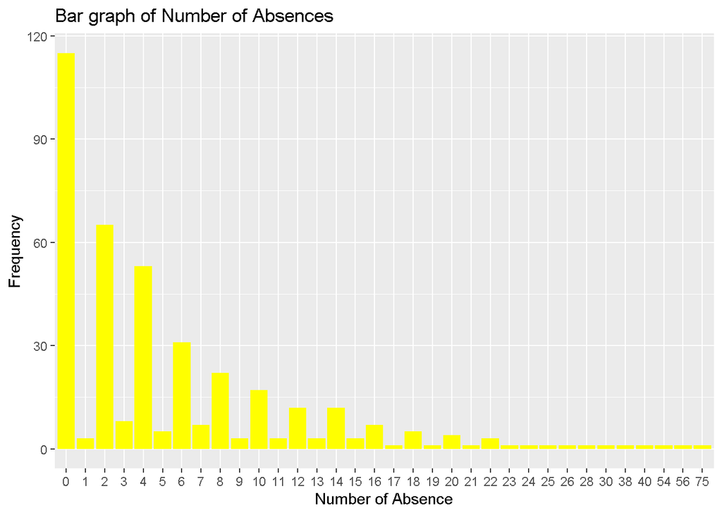

```r
#(2)using geom_bar (data:absences)
ggplot() +
  geom_bar(aes(x=Var1,y=Freq),fill="yellow",data=absences,
           stat="identity") +
          labs(x="Number of Absence",y="Frequency",
        title="Bar graph of Number of Absences")
```

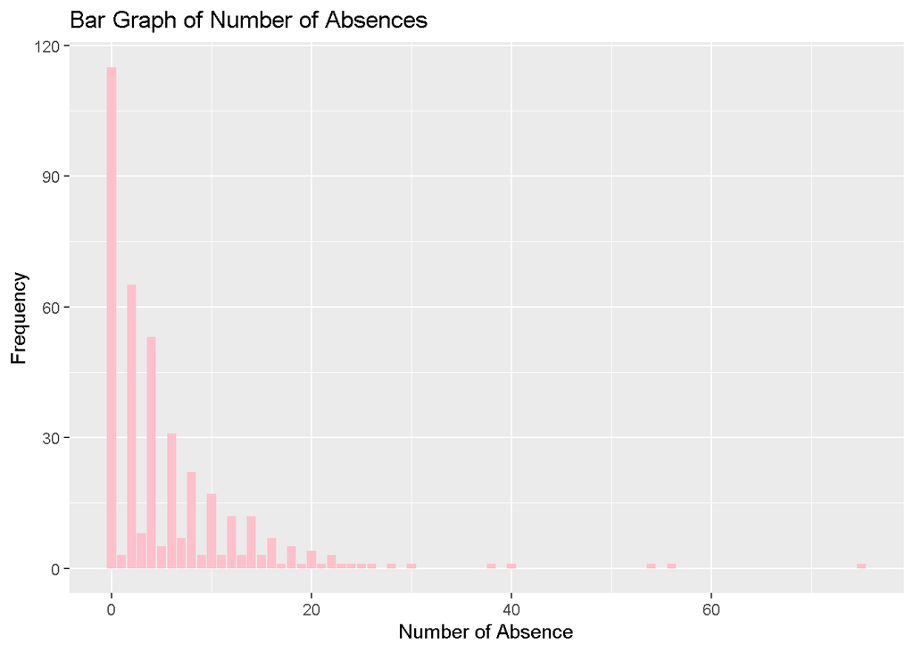

```r
#(3)using geom_bar (data :math)
ggplot() +
  geom_bar(aes(x=absences),fill="pink",
          data=math)+
  labs(x="Number of Absence",y="Frequency",
       title="Bar Graph of Number of Absences")
```

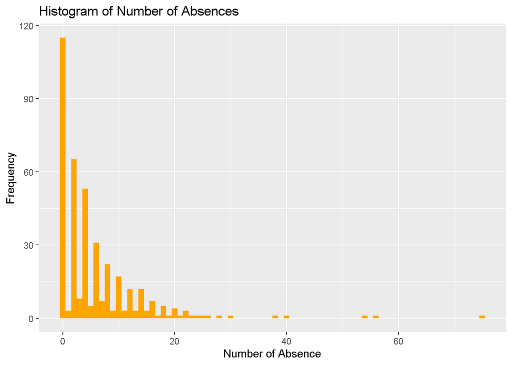

```r
#(4)using geom_histogram
ggplot() +
  geom_histogram(aes(x=absences),
                 fill="orange",
                 binwidth=1,data=math)+
  labs(x="Number of Absence",y="Frequency",
       title="Histogram of Number of Absences")
```

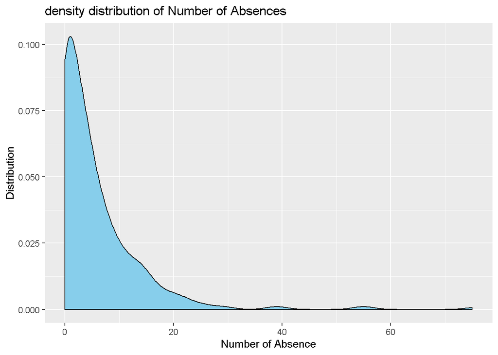

```r
#(5)using geom_density
ggplot() +
  geom_density(aes(x=absences),fill="skyblue",data=math)+
  labs(x="Number of Absence",y="Distribution",
       title="density distribution of Number of Absences")
```

#7.answer: The distribution is very skewed to right (longer tail toward right.) and most of absences are gathered near zero and the shape is similiar to gamma distribution

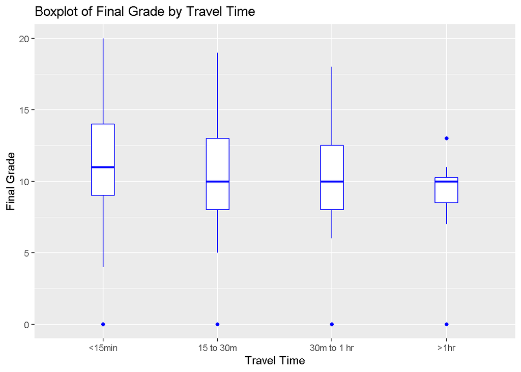

```r
#8. code:
#(1)traveltime_labeled was also created in problem5
# for better labeling and class change ( into "factor" variable).

math$traveltime_labeled <- factor(math$traveltime,
                                  labels=c("<15min","15 to 30m", "30m to 1 hr",">1hr"))
math$traveltime_labeled <- ordered(math$traveltime,
                    labels=c("<15min","15 to 30m",
                             "30m to 1 hr",">1hr"))

#(2)Create a boxplot to show the relationship between travel time and final grade.
ggplot()+
  geom_boxplot(aes(x=traveltime_labeled, y=G3),
  width=.2,fill="white", color="blue", data=math)+
  labs(x="Travel Time",
       y="Final Grade",
       title="Boxplot of Final Grade by Travel Time")
```

#8. answer: #There are outliers in final grade=0 for all groups. For those observations, maybe instead of travel time, other factors could have affect them and we can have a further investigation. (continued in problem 9)

#The medians for final grade are all around 10 or a little above for all travel times and the first and third quartiles do not seem very different (except the longer than 1 hour.) Therefore, it does not look like there is much impact of travel time on final grade.